```python
from IPython.display import HTML
HTML('''<script>
code_show=true;
function code_toggle() {
 if (code_show){
 $('div.input').hide();
 } else {
 $('div.input').show();
 }
 code_show = !code_show
}
$( document ).ready(code_toggle);
</script>
<form action="javascript:code_toggle()"><input type="submit" value="Click here to toggle on/off the raw code."></form>''')
```

# 🐍 [One Point Tutorial] Visualization I - `matplotlib`

Python을 활용한 데이터 시각화

December, 2019 | All rights reserved by Wooseok Song

### ☝ 시각화 튜토리얼을 들어가기 전,

### 우리는 데이터 시각화를 왜 해야할까?

#### 1. 데이터를 한 눈에 살펴 볼 수 있다.

#### 2. 데이터 지식이 부족한 사람도 시각화를 통하여 데이터를 쉽게 이해할 수 있다.

#### 3. 데이터에 대한 인사이트 공유가 가능해지기 때문에 데이터 기반의 효율적인 의사 소통이 가능해진다.

#### 4. 데이터 시각화가 쓰일 수 있는 분야는 무궁무진하다.

#### 5. EDA 등 전처리 단계에서 이슈를 빠르게 파악할 수 있다.

#### 6. AUROC 등 머신러닝의 성과 평가에 유용하게 활용된다.

#### 7. ...

## 1. *matplotlib* 을 배워 보자 !

- **matplotlib 이란?**  
  파이썬의 대표적인 데이터 시각화 라이브러리  
  핵심적인 시각화 기법을 대다수 적용 가능

### 학습 목표

`matplotlib`의 핵심적인 시각화 기법을 이해하고 활용함

### Import module (모듈 설치 후 불러오기)

matplotlib 모듈이 설치 안 되어 있다면, 설치부터 하기!

```python
import numpy as np
import pandas as pd

import matplotlib as mpl
import matplotlib.pyplot as plt
%matplotlib inline
# 주피터 노트북 사용하는 경우 실행

import os
```

```python
try:
    os.chdir("C:\\Users\\wsSONG\\Desktop\\WORKS\\3.DAT\\191220")
    print("Current Working Directory is changed.")
except OSError:
    print("Can't change Current Working Directory.")
```

```
Current Working Directory is changed.
```

### 1.1. 가장 간단한 그래프 , Line Plot

가장 간단한 플롯은 선을 그리는 라인 플롯(line plot)이다.  
라인 플롯은 데이터가 시간, 순서 등에 따라 어떻게 변화하는지 보여주기 위해 사용한다.

> **사용 방법 :**  
> plt.`plot`(`x데이터`, `y데이터`)

#### 1.1.1. 첫번째 그래프 : 주어진 데이터가 하나일 때 (plot 함수의 데이터 인자가 1개일 때)

이런 경우, x축은 0, 1, 2, 3, ... 으로 자동 지정되고 넣은 데이터는 각 x축에 대응하는 y값이 된다.  
확인해보자!

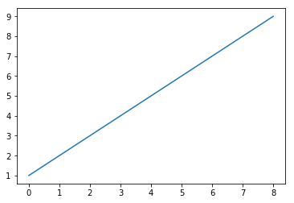

```python
x = np.arange(1, 10)

plt.plot(x)
plt.show() #그래프를 보여줘!
```

(0, 1), (1, 2), ... , (8, 9)를 지나는 것을 확인할 수 있다.

#### 1.1.2. 두번째 그래프 : x, y축 데이터들이 모두 주어졌을 때

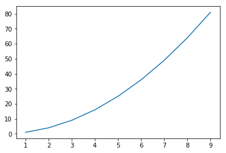

```python
x = np.arange(1, 10)
y = x**2

plt.plot(x, y)
plt.show() #그래프를 보여줘!
```

x,y 데이터가 (x, y) 좌표쌍으로 표현되어 그래프에 나타나는 것을 확인할 수 있다.

#### 1.1.3. 세번째 그래프 : 라인의 컬러 바꾸기

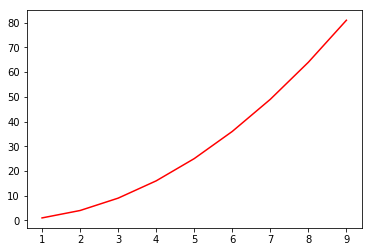

```python
x = np.arange(1, 10)
y = x**2

plt.plot(x, y, 'r') #위의 코드에서 'r'추가
plt.show() #그래프를 보여줘!
```

코드에 'r'을 추가한 것만으로 그래프가 빨간색으로 그려진 것을 확인할 수 있다.  
'r'은 red의 약자이고, 색을 지정하려면 plot에서 인자를 하나 추가해주면 된다.

### 색상표

| 문법 | 색 |
| --- | --- |
| 'b' | blue |
| 'g' | green |
| 'r' | red |
| 'c' | cyan |
| 'm' | magenta |
| 'y' | yellow |
| 'k' | black |
| 'w' | white |

#### 1.1.4. 네번째 그래프 : 라인 마커 변경하기

다양한 선의 종류를 선택할 수 있다. default 값은 직선이고, 점으로 표현하는 마커나 점선 등을 원한다면 선택할 수 있다.  
선의 종류는 plot에서 인자로 지정하면 되고, 색을 같이 지정하려면 같은 인자에 함께 문자형으로 색을 지정하면 된다.  
예시를 살펴보자! 동그란 마커 ‘o’를 붉은색 ‘r’로 표현하기 때문에, 세번째 인자를 ‘or’로 전달하였다.

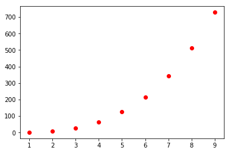

```python
x = np.arange(1,10)
y = x**3

plt.plot(x,y,'or') #여기서 r은 red인데 o가 또 추가되었네!
plt.show()
```

위의 그래프들은 line plot이었는데 이번에는 선이 아닌 점으로 그려진 것을 확인할 수 있다.

### 마커 종류

| 문법 | 종류 |
| --- | --- |
| '-' | solid line style |
| '--' | dashed line style |
| '-.' | dash-dot line style |
| ':' | dotted line style |
| '.' | point marker |
| ',' | pixel marker |
| 'o' | circle marker |
| 'v' | triangle down marker |
| '^' | triangle up marker |
| '<' | triangle left marker |
| '>' | triangle right marker |
| '1' | tri down marker |
| '2' | tri up marker |
| '3' | tri left marker |
| '4' | tri right marker |
| 's' | square marker |
| 'p' | pentagon marker |
| `*` | star marker |
| '+' | plus marker |
| 'x' | X marker |
| 'D' | diamond marker |

한 번 더 복습해보자.  
위 plot의 마커를 초록색 별로 변환해보라.

[figure not shown]

```python
plt.plot(x, y, '*g')
plt.show()
```

#### 1.1.5. 다섯번째 그래프 : 축의 이름 / 그래프 제목 달기

> **사용 방법:**
> 1. x축 이름 : plt.xlabel(`x축 이름`)
> 2. y축 이름 : plt.ylabel(`y축 이름`)
> 3. 그래프 제목 : plt.title(`그래프 제목`)

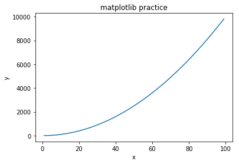

```python
x = np.arange(1, 100)
y = x**2

plt.plot(x, y)
plt.xlabel('x') # x축 이름 지정
plt.ylabel('y') # y축 이름 지정
plt.title('matplotlib practice') # 그래프 이름 지정

plt.show()
```

x축 이름/ y축 이름/ 그래프 제목이 생긴 것을 확인할 수 있다 !

#### 1.1.6. 여섯번째 그래프: 구간 설정

x축과 y축의 구간을 설정할 수 있다.

> **사용 방법:**
> 1. x축 구간 설정 : plt.xlim(시작 범위, 끝 범위)
> 2. y축 구간 설정 : plt.ylim(시작 범위, 끝 범위)

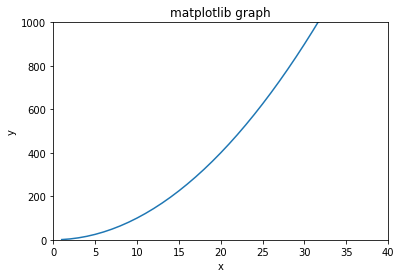

```python
plt.plot(x, y)
plt.xlabel('x')
plt.ylabel('y')
plt.title('matplotlib graph')
plt.xlim(0, 40)
plt.ylim(0, 1000)
plt.show()
```

x축은 0에서 40의 범위만, y축은 0에서 1000의 범위만 나타내고 있는 것을 확인할 수 있다.

#### 1.1.7. 일곱번째 그래프: 범주 달기 (legend)

여러 개의 그래프를 같이 그리는 경우가 존재하고, 이 경우 각 그래프를 구분하기 위해 그래프마다 라벨을 부여해 출력  
이를 범주(legend)라고 한다.

> **사용 방법:**  
> plt.legend(loc = `원하는 위치`) #위치 지정해주어야 함

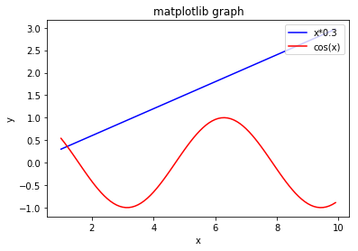

```python
x = np.arange(1,10,0.1)
y1 = x*0.3
y2 = np.cos(x)

plt.plot(x,y1,'b',label='x*0.3') #파란색 / first 라벨 부여
plt.plot(x,y2,'r',label='cos(x)') #빨간색 / second 라벨 부여
plt.xlabel('x')
plt.ylabel('y')
plt.title('matplotlib graph')
plt.legend(loc='upper right') # 범주 표현

plt.show()
```

#### 1.1.8. 여덟번째 그래프: 어노테이션 (화살표로 가리키기)

그래프에 화살표를 그린후, 그 화살표에 문자열을 출력하는 기능

> **사용 방법:**  
> plt.annotate(`원하는 문자열`, xy(화살표 꼭지 xy좌표), xytext(문자열 xy 좌표), arrowprops(화살표 속성 ex.color))

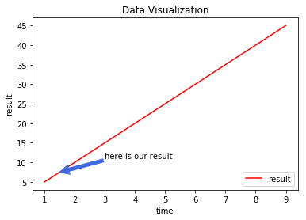

```python
x = np.arange(1, 10)
y = x*5

plt.plot(x, y, 'r', label = 'result')
plt.xlabel('time')
plt.ylabel('result')
plt.title('Data Visualization')
plt.legend(loc = 'lower right')
plt.annotate('here is our result', xy = (1.5, 7.5), xytext = (3, 11), arrowprops = {'color': 'royalblue'})
plt.show()
```

(1.5, 7.5)의 위치를 가리키는 화살표가 생긴 것을 확인할 수 있다.

#### 1.1.9. 아홉번째 그래프: 서브 플롯 그리기

여러 개의 그래프를 그리고 싶을때 서브플롯을 사용

> **사용 방법:**  
> plt.subplot(`nrow`,`ncol`,`pos`)

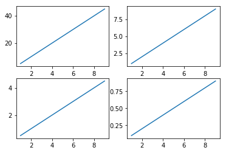

```python
x = np.arange(1,10)
y1 = x*5
y2 = x*1
y3 = x*0.5
y4 = x*0.1

plt.subplot(2,2,1) #2행 2열 (2X2) 그래프 중 (1,1)의 위치
plt.plot(x,y1)

plt.subplot(2,2,2) #2행 2열 (2X2) 그래프 중 (1,2)의 위치
plt.plot(x,y2)

plt.subplot(2,2,3) #2행 2열 (2X2) 그래프 중 (2,1)의 위치
plt.plot(x,y3)

plt.subplot(2,2,4) #2행 2열 (2X2) 그래프 중 (2,2)의 위치
plt.plot(x,y4)

plt.show()
```

그래프가 그려지는 순서는 행방향으로 진행된다는 것을 알 수 있다.

#### 1.1.10. 열번째 그래프: 그래프 사이즈

> **사용 방법:**  
> plt.figure(figsize=(`가로`,`세로`))

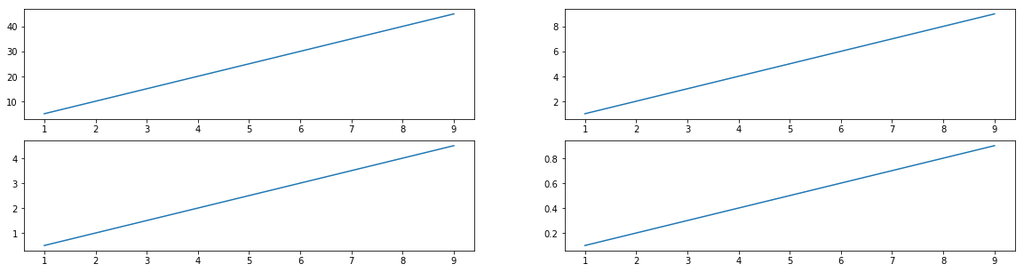

```python
x = np.arange(1,10)
y1 = x*5
y2 = x*1
y3 = x*0.5
y4 = x*0.1

plt.figure(figsize=(20,5)) #가로 20, 세로 5로 설정

plt.subplot(2,2,1)
plt.plot(x,y1)

plt.subplot(2,2,2)
plt.plot(x,y2)

plt.subplot(2,2,3)
plt.plot(x,y3)

plt.subplot(2,2,4)
plt.plot(x,y4)

plt.show()
```

figsize를 어떤 숫자로 지정하느냐에 따라 그래프의 크기가 달라진다.

#### 1.1.11. 열한번째는 팁: plt 기타 스타일 참고

| 스타일 문자열 | 약자 | 의미 |
| --- | --- | --- |
| `color` | `c` | 선 색깔 |
| `linewidth` | `lw` | 선 굵기 |
| `linestyle` | `ls` | 선 스타일 |
| `marker` |  | 마커 종류 |
| `markersize` | `ms` | 마커 크기 |
| `markeredgecolor` | `mec` | 마커 선 색깔 |
| `markeredgewidth` | `mew` | 마커 선 굵기 |
| `markerfacecolor` | `mfc` | 마커 내부 색깔 |

### 1.2. Bar Plot

라인 플롯은 *연속적인 x*에 따른 y의 변화를 살펴보는 데에 효과적이라면, 막대 차트는 *연속적이지 않은 x*에 따른 y의 변화를 살펴보는 데에 효과적이다.

> **사용 방법:**
> 1. plt.bar(`x`, `height`, `width`, `align`)  
>    **width:** 막대 두께 조절  
>    **align:** 'center'와 'edge' (기본값 'center')  
>    x축 label 막대의 중간 위치(center) 또는 왼쪽 가장자리 위치(edge) 설정
> 2. `데이터`.plot(kind = 'bar')

#### 1.2.1. 첫번째 그래프: 첫번째 방법으로 막대 차트 그리기

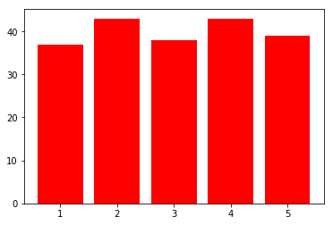

```python
x = np.random.randint(1, 6, size = 200)
name, count = np.unique(x, return_counts = True) # 각 빈도수를 count에 반환

plt.bar(name, count, color = 'red')
plt.show()
```

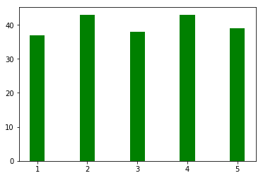

```python
plt.bar(name, count, width = 0.3, color="green") #width 조절
plt.show()
```

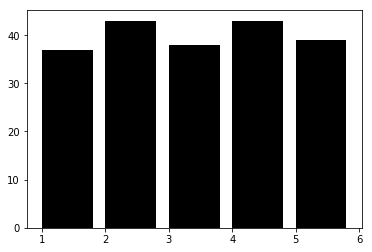

```python
plt.bar(name, count, align='edge', color="k") # x축 text-align 설정
plt.show()
```

#### 1.2.1. 두번째 그래프: 막대 방향을 수평으로 바꾸기

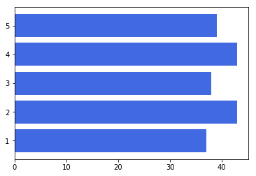

```python
plt.barh(name, count, color="royalblue") # bar에서 barh로!
plt.show()
```

#### 1.2.1. 세번째 그래프: 양쪽으로 막대차트 그리기

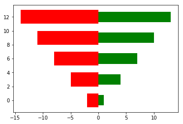

```python
x=np.arange(15).reshape((5, 3))
plt.barh(x[:,0], x[:,1], color='g', height=1.5) # 여기서 height는 bar 굵기!
plt.barh(x[:,0], -x[:,2], color='r', height=2)
plt.show()
```

#### 1.2.1. 네번째 그래프: 두번째 방법으로 막대 차트 그리기

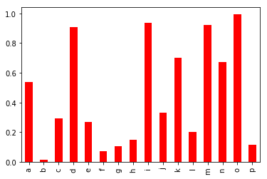

```python
data = pd.Series(np.random.rand(16), index=list('abcdefghijklmnop'))

data.plot(kind='bar', color="r")
plt.show()
```

#### 1.2.1. 다섯번째 그래프: 막대 방향 수평으로 바꾸기

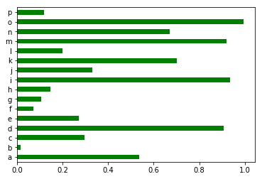

```python
data.plot(kind='barh', color="green") # bar에서 barh로 !
plt.show()
```

#### 1.2.1. 여섯번째 그래프: data.frame을 그래프로 그리기

```python
df2 = pd.DataFrame(np.random.rand(6,4),
                  index = ['1','2','3','4','5','6'],
                  columns = pd.Index(['A','B','C','D'], name='column'))
df2.head()
```

| column | A | B | C | D |
| --- | --- | --- | --- | --- |
| 1 | 0.547922 | 0.005280 | 0.742668 | 0.354096 |
| 2 | 0.732152 | 0.321847 | 0.513796 | 0.981808 |
| 3 | 0.129532 | 0.634703 | 0.983994 | 0.585614 |
| 4 | 0.212694 | 0.622099 | 0.614847 | 0.572731 |
| 5 | 0.607056 | 0.239213 | 0.303188 | 0.023149 |

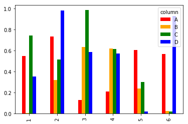

```python
df2.plot(kind='bar', color=['red','orange','green','blue'])
plt.show()
```

#### 1.2.1. 일곱번째 그래프: Stacked Bar Chart

[figure not shown]

```python
df2.plot(kind='bar', stacked=True)
plt.show()
```

[figure not shown]

```python
df2.plot(kind='barh', stacked=True) # 막대 수평방향으로 쌓는 형식으로 보여줘!
plt.show()
```

### 1.3. Histogram

히스토그램은 확률분포의 그래픽적인 표현으로 막대그래프 중 한 종류. 확률분포와 관계가 있으므로 통계적 요소를 나타내기 위해 많이 사용한다.

> **사용 방법:**  
> plt.hist(`data`, bins = `숫자`, density = True or False(False가 default))

`bins`는 구간의 개수를 의미하고, `density=True`는 빈도수가 아닌 비율로 나타내는 것을 의미한다.

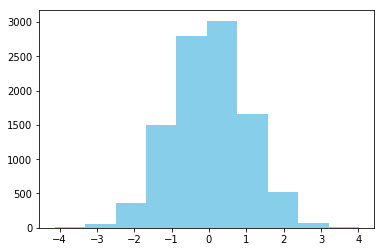

```python
x=np.random.randn(10000)
plt.hist(x, color='skyblue') #bins default는 10
plt.show()
```

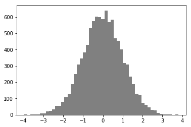

```python
x=np.random.randn(10000)
plt.hist(x, color='grey', bins=50) #구간의 개수를 50개
plt.show()
```

[figure not shown]

```python
plt.hist(x, density=True, color='lightpink') #빈도수가 아닌 확률로!
plt.show()
```

### 1.4. Pie Chart

1차원의 데이터를 인자로 전달하면 데이터의 상대적 면적을 자동으로 계산하여 그래프를 그려주는 것이 파이차트이다.  
단일 범주형 변수 대상으로 구성비를 확인하는 데 유용하다.

> **사용 방법:**  
> plt.pie(`data`)

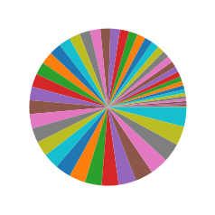

```python
plt.pie(np.arange(50))
plt.show()
```